# Iramuteqerako euskarazko lexikoa V0.1, aurkezpena

Goi-Mailako Hezkuntza Berrikuntza Nazioarteko Kongresua Leioan, 2022 apirilean

Juan Abasolo

Naia Eguskiza

[figure not shown]

### Reinert metodoaz

## Kontzeptua

**Lehen Hezkuntzak 6-12 urte arteko nahitaezko hezkuntza aldia barne hartzen du.** Etapa honen helburua da haurrek garapen pertsonala zein sozio-kulturala izan dezaten laguntzea, bai eta euren bizitza osoan zehar izango duten ikaskuntzarako oinarriak prestatzen laguntzea ere. Irakaslearen irudia funtsezkoa da etapa honetan.

- Lehen Hezkuntzak 6-12 urte arteko nahitaezko hezkuntza aldia barne hartzen du
- Lehen Hezkuntzak 6-12 urte arteko nahitaezko hezkuntza aldia barne hartzen du.
- lehen hezkuntzak 6-12 urte arteko nahitaezko hezkuntza aldia barne hartzen du.
1. `lehen hezkuntza urte arte aldi barne hartu`  
   *Lehen Hezkuntzak 6-12 urte arteko nahitaezko hezkuntza aldia barne hartzen du*.
2. `etapa helburu haur garapen pertsonal soziokultural lagunt bizitza ikaskuntza oinarri`  
   *Etapa honen helburua da haurrek garapen pertsonala zein sozio-kulturala izan dezaten laguntzea, bai eta euren bizitza osoan zehar izango duten ikaskuntzarako oinarriak prestatzen laguntzea ere.*
3. `irakasle irudi funts etapa`  
   *Irakaslearen irudia funtsezkoa da etapa honetan.*

### Euskaraz

from / of / at *home*

*etxe*ko  
*etxe*koa  
*etxe*koaren  
*etxe*an  
*etxe*tik  
…

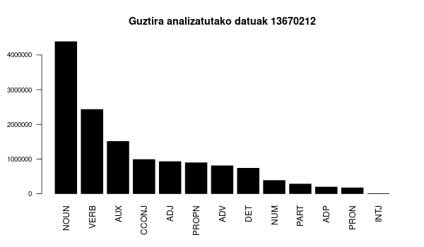

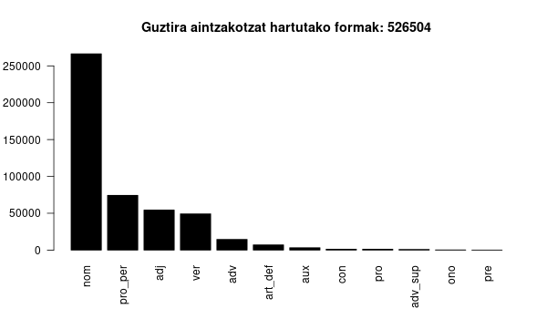

### Adibidea

## LH eta HHko irakasleok

|  | Bilbo | Donostia | Gasteiz |
| --- | --- | --- | --- |
| denera | 116 | 90 | 92 |
| deskribatuak | 80 | 47 | 44 |

- 1.329 zentzu unitate
- 20.238 gertaldi
- 3.918 forma
- 2.374 hapax

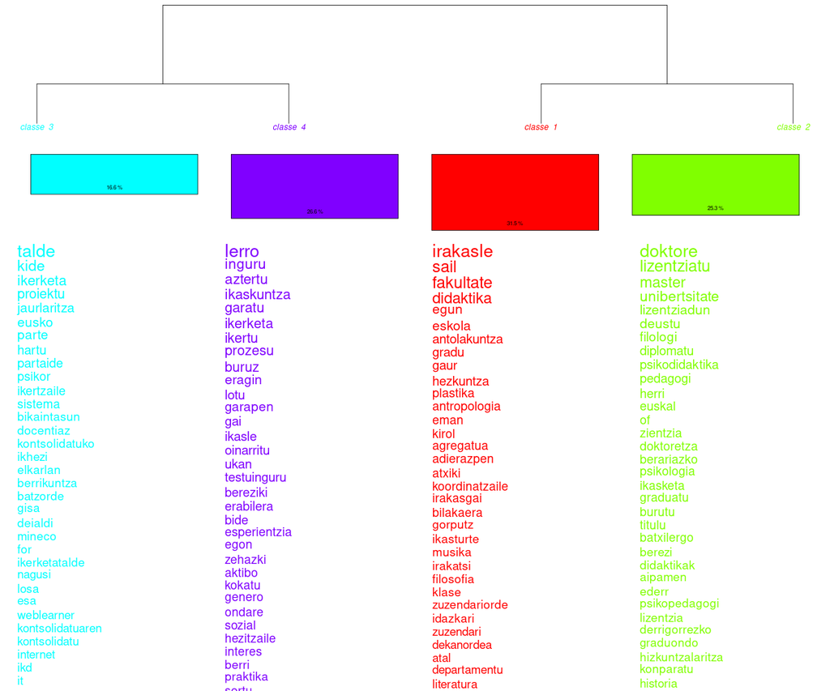

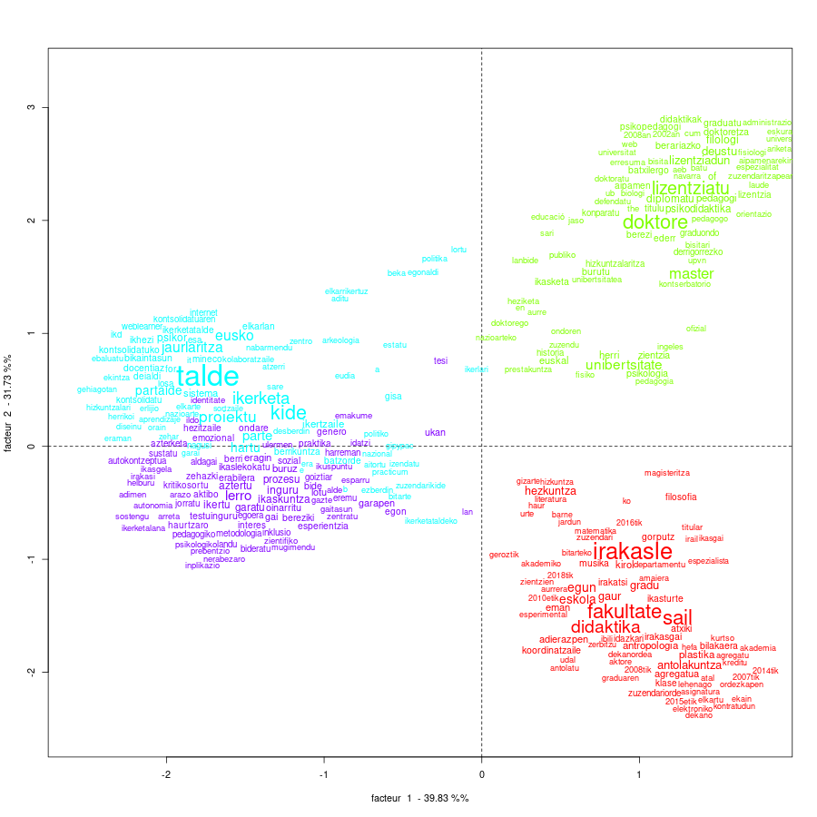

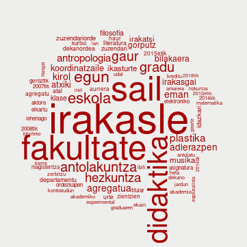

> gaur egun irakasle atxikia da bilboko hezkuntza fakultateko didaktika eta eskola antolakuntza sailean haur hezkuntzako graduan eskola antolakuntza irakasgaia irakasten

> egun musika plastika eta gorputz adierazpenaren didaktikaren saileko irakasle atxikia naiz haur hezkuntzako graduan garapen psikomotorra eta haur hezkuntzako lehen ziklorako estrategia eta teknika psikomotor irakasgaiak ematen bilboko hezkuntza fakultatean

> gaur egun irakasle atxikia naiz ehuko hezkuntza filosofia eta antropologia fakultatean didaktika et eskola antolakuntza sailean

> egun irakasle atxikia da gizarte zientzien didaktika sailean eta hezkuntza filosofia eta antropologia fakultatean hefa ematen ditu eskolak

> bilboko hezkuntza fakultatean teoria eta historiako departamentuan irakasle elkartua izandakoa 2017 2018 gaur egun didaktika eta eskola antolakuntza saileko irakaslea leioa upv ehu

### Orain zer?

## Erabiltzeko

**OSF**

## Hutsuneak

Nafar / Iparraldeko moldeak azpi-ordezkatua

Txarto sailkatuak :  
`daroat daroat nom`  
`zutelakotz zutelakotz nom`  
([`+`](https://erabili.liberaforms.org/iramuteqlexikorako))

Izen propioak

**arte** lanak egin zituen Vs *lanak egin zituen **arte***

# Juan Abasolo - Naia Eguskiza

kontaktua : `juan . abasolo @ ehu . eus`